# Reproducible Research: Peer Assessment 1

## Loading and preprocessing the data

1. **Remove all variables from the environment to setup a clear environment**

```r
#clear environment vars
rm(list=ls(all=TRUE))
```

2. **Read the data into dataframe**

```r
activity <- read.csv('activity.csv', header = T)
```

## What is mean total number of steps taken per day?

Summarize the data by day:

```r
library(data.table)
activity_tbl <- data.table(activity)
activity_tbl_summary <- activity_tbl[, list(total_steps = sum(steps, na.rm = T)),
                          by = date]
```

**Create histogram and report on mean and median:**

Following items will be addressed in below histogram:

- Make a histogram of the total number of steps taken each day
- Calculate and report the mean and median total number of steps taken per day

[figure not shown]

```r
library(ggplot2)
# Single function to create histogram and add lines and legend for mean and median
plot_hist <- function(x, title){
        hist(x,
             breaks = 20,
             main = title,
             xlab = 'Number of steps taken', col = 'light grey',
             cex.main = .9)

        #caluclate mean and median
        meanVal = round(mean(x), 1)
        medianVal = round(median(x), 1)

        #draw lines for mean and median on histogram
        abline(v=meanVal, lwd = 3, col = 'red')
        abline(v=medianVal, lwd = 3, col = 'blue')

        #legend
        legend('topright', lty = 1, lwd = 3, col = c("red", "blue"),
               cex = .8,
               legend = c(paste('Median: ', medianVal),
                          paste('Mean: ', meanVal))
               )
}

plot_hist(activity_tbl_summary$total_steps, 'Number of steps taken each day')
```

## What is the average daily activity pattern?

Following items will be addressed in below plot:

- Make a time series plot (i.e. type = “l”) of the 5-minute interval (x-axis) and the average number of steps taken, averaged across all days (y-axis)
- Which 5-minute interval, on average across all the days in the dataset, contains the maximum number of steps?

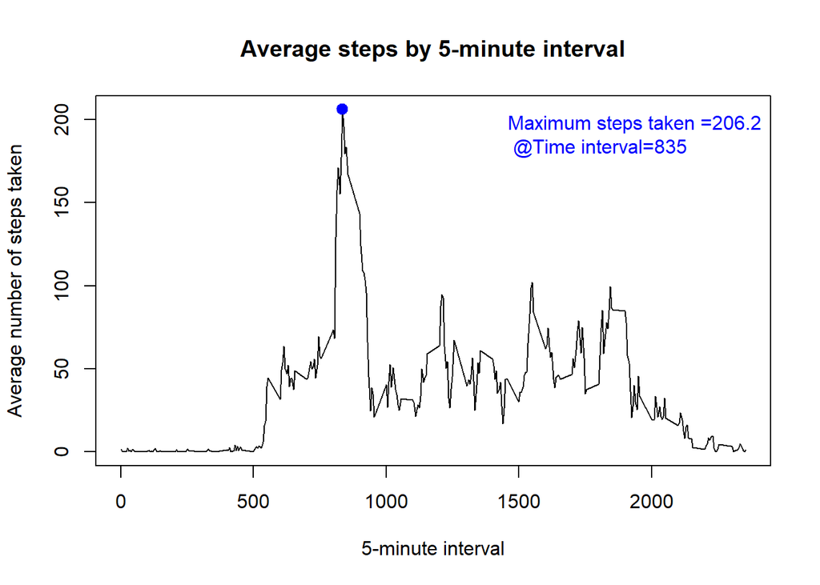

```r
#summarize dataset by interval
activity_tbl_summary_intv = activity_tbl[, list(avg_steps = mean(steps, na.rm = T)),
                          by = interval]
#plot the time series
with(activity_tbl_summary_intv, {
        plot(interval, avg_steps, type = 'l',
             main = 'Average steps by 5-minute interval',
             xlab = '5-minute interval',
             ylab = 'Average number of steps taken')
        })
#find Interval with maximum avg steps
max_steps = activity_tbl_summary_intv[which.max(avg_steps), ]

#legend label String
max_lab = paste('Maximum steps taken =', round(max_steps$avg_steps, 1), '\n @Time interval=', max_steps$interval, sep = '')

#get cooridinates of max Interval
points(max_steps$interval,  max_steps$avg_steps, col = 'blue', lwd = 3, pch = 19)

#Add legend for maximum # steps and interval
legend("topright",
       legend = max_lab,
       text.col = 'blue',
       bty = 'n'
       )
```

## Imputing missing values

1. Calculate & report number of missing values

```r
sum(is.na(activity$steps))
```

```
## [1] 2304
```

- Devise a strategy for filling in all of the missing values in the dataset. The strategy does not need to be sophisticated. For example, you could use the mean/median for that day, or the mean for that 5-minute interval, etc.
- Create a new dataset that is equal to the original dataset but with the missing data filled in.

```r
#join the dataframe return(y)average number of steps per interval to the original dataset
setkey(activity_tbl, interval)
setkey(activity_tbl_summary_intv, interval)

#create new dataset having average values in place of NAs
activity_tbl_miss = activity_tbl[activity_tbl_summary_intv]
activity_tbl_miss$new_steps = mapply(function(val1,val2){if(is.na(val1)) return(val2) else return(val1) },activity_tbl_miss$steps, activity_tbl_miss$avg_steps)

#summaryize new dataset by day
activity_tbl_summary_miss = activity_tbl_miss[, list(new_steps = sum(new_steps, na.rm = T)),
                          by = date]
```

[figure not shown]

```r
plot_hist(activity_tbl_summary$total_steps, 'Without missing values')
```

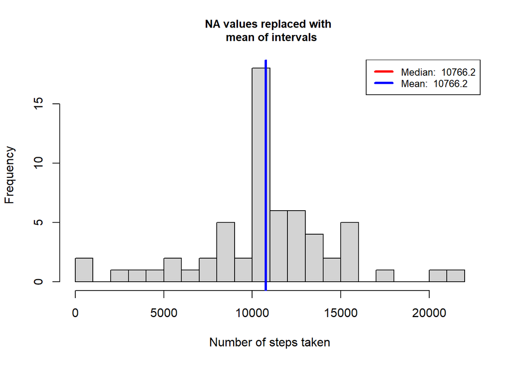

```r
# As mean and median will be same in this case so median will be overlapped by mean line
plot_hist(activity_tbl_summary_miss$new_steps, 'NA values replaced with \n mean of intervals')
```